# Data Manipulation and GGplot

Neil Lund

2024-09-17

# Quick notes on HW1

## 1. Avoid loops if you can

- Interpreted languages like R are usually slower than compiled languages like C or Java. Especially when it comes to loops.
- Many R functions like `sum` and `mean` actually use compiled C code. These will always be faster than an equivalent R loop.

### Example:

```r
library(microbenchmark)

sumFunction<-function(x){
  s <- 0
  for(i in x){
    s<-s+x
  }
  return(s)
}

set.seed(999)
myvec <- rnorm(1000)

comparison<-microbenchmark(sum(myvec), sumFunction(myvec))

summary(comparison)
```

| expr | min | lq | mean | median | uq | max | neval | cld |
| --- | --- | --- | --- | --- | --- | --- | --- | --- |
| sum(myvec) | 700 | 900 | 1579 | 1200 | 1800 | 15200 | 100 | a |
| sumFunction(myvec) | 529400 | 617100 | 1735182 | 697300 | 2491900 | 10028300 | 100 | b |

## 2. What happens in braces

Think of `{}` as denoting a special little environment where the `for`, `if`, and `function` code executes.

`if` statement

```r
if(1 == 2){
  print("1 equals 2 for some reason.")
}
```

`for` loop

```r
for(i in 1:10){
  print("code that runs 10 times")
}
```

`function` definition

```r
pFunc<-function(x){
  y <- "some data"
  z <- "even more data"
  return(z)
}
```

- In `if` statements, the `{}` denotes conditional code that only runs if the `if()` statement is `TRUE`
- In `for`, `while` and `repeat` loops, the `{}` denotes the code that gets repeated
- in `function` definitions, the `{}` denotes the code that gets evaluated when you call the function.

### 2b. And functions only know what you give them

Outside of some specific cases, code inside a `function` doesn’t have access to data unless you pass that data as a function argument. The function signature (the part in parentheses) is like a template where you tell the function what data to expect.

This can’t work:

```r
printFunction<- function(){
  print(x)
}

printFunction("Print this")
```

```
Error in printFunction("Print this"): unused argument ("Print this")
```

And neither does this:

```r
printFunction<- function(x){
  print(x)
}

print()
```

```
Error in print.default(): argument "x" is missing, with no default
```

We have to define a function that takes x, and then we have to supply x when we call the function:

```r
printFunction<- function(x){
  print(x)
}

printFunction("Print this")
```

```
[1] "Print this"
```

## 3. Go one step at a time

When you’re stuck:

**Start by clearing the R environment** by restarting or pressing the little broom in the top right

## 3. Go one step at a time

Next: **Break things up:** so you can run a single line of code and then pause and see what changed by checking your environment, using `View()`, printing to the console, or reading help files.

Instead of this:

```r
cumsum(log(exp(seq(10))))
```

```
 [1]  1  3  6 10 15 21 28 36 45 55
```

Or this:

```r
seq(10)|>
  exp()|>
  log()|>
  cumsum()
```

```
 [1]  1  3  6 10 15 21 28 36 45 55
```

Do this and then look at what happens after each line:

```r
x<- seq(10)

xexp<-exp(x)

xlog<-log(xexp)

xcumulative<-cumsum(xlog)

xcumulative
```

```
 [1]  1  3  6 10 15 21 28 36 45 55
```

Pipes and nested parentheses make it easier to write code, but its more important to figure stuff out. So just break it out and (if needed) clean it up once you understand what is going on.

# Split-Apply-Combine operations

## Split-Apply-Combine

Many analysis problems require users to use what [Hadley Wickham calls the Split-Apply-Combine Strategy](https://www.jstatsoft.org/article/view/v040i01):

- Break up the data into groups (split)
- Do something to each of the groups separately (apply)
- Recombine the results (combine)

Examples:

- Calculate GPAs by student/semester from a list of class grades
- Get the average age of members of Congress in each party
- Calculate the total number of protests by year in democracies compared to autocracies

### Split-Apply-Combine

Say I want the top party for each country-year from the CHES data.

```r
library(tidyverse)
url<-'https://www.chesdata.eu/s/1999-2019_CHES_dataset_meansv3-y4tg.dta'
ches<-haven::read_dta(url)|>
  arrange(country, year)|>
  as_factor()
```

### Split-Apply-Combine: Looping

I could use a loop, but this seems like a lot of code to write for a seemingly simple problem:

```r
# unique countries
countries<-unique(ches$country)
results<-data.frame()
# loop through each country
for(i in countries){
  # get country i
  ches_country<-subset(ches, country == i)
  # get years in country i
  years <- unique(ches_country$year)
  # loop through year j in country i
  for(j in years){
    ches_year <- subset(ches_country, year == j)
    # get the top party for ij
    top_party <- subset(ches_year,
                        select = c(country, party, year),
                        seat == max(seat, na.rm=TRUE))
    # add to results
    results<-rbind(results, top_party)
  }
}
```

### Split-Apply-Combine: apply functions

We could also use built in R functions like `split` with `apply` functions (these basically generate loops automatically) but the syntax here is not always consistent or intuitive:

```r
datasplits<-split(ches, ~country + year)

top_party<-sapply(datasplits, function(x) x$party[which.max(x$seat)])

head(top_party)
```

```
$be.1999
[1] "PVV/VLD"

$dk.1999
[1] "SD"

$ge.1999
[1] "SPD"

$gr.1999
[1] "PASOK"

$esp.1999
[1] "PP"

$fr.1999
[1] "PS"
```

### Split-Apply-Combine: dplyr

The [`dplyr` package](https://dplyr.tidyverse.org/) provides a set of consistent functions for data manipulation problems, including `split-apply-combine`.

`dplyr` is loaded automatically when you call `library(tidyverse)`, and its meant to integrate easily with other tidy packages.

We can solve the problem above with three codes

```r
ches|>
  group_by(country, year)|>
  slice_max(seat)|>
  select(country, year, party)
```

| country | year | party |
| --- | --- | --- |
| be | 1999 | PVV/VLD |
| be | 2002 | VLD |
| be | 2006 | PS |
| be | 2006 | VLD |
| be | 2010 | NVA |
| be | 2014 | NVA |
| be | 2019 | VU/NVA |
| dk | 1999 | SD |
| dk | 2002 | V |
| dk | 2006 | V |

[output cut: 10 more lines]

### Split-Apply-Combine: dplyr

Additionally, all `dplyr` functions:

- allow you to give a data set as a function argument (so they work well with the `|>` pipe operator)
- return a `tibble` (a kind of data frame that we can easily use with other packages)
- have close analogs in `SQL` (which can make it easier to learn one if you know the other)

# dplyr

## Example: Crowd Counting Consortium Data

[The Crowd Counting Consortium](https://github.com/nonviolent-action-lab/crowd-counting-consortium) dataset contains machine-coded data on protest activity in the US from 2017-present. We’ll use a subset of that data covering 2017-2020 for an example.

```r
url<-"https://github.com/nonviolent-action-lab/crowd-counting-consortium/raw/master/ccc_compiled_2017-2020.csv"
ccc<-read_csv(url)

# there's a lot of data here
nrow(ccc)
```

```
[1] 72181
```

Note: this is messy data! And pretty much anything interesting we can do with it ill require a little wrangling.

## group_by

For the “Split” step, we’ll use the (inaptly named) `group_by` operation.

On its own, its not always clear that this function really does anything except change the class of our data to a `grouped_df`. The utility isn’t apparent until the next step, but under-the-hood, we’ve split these data by state.

```r
ccc_grouped<-ccc|>
  group_by(state)

class(ccc)
```

```
[1] "spec_tbl_df" "tbl_df"      "tbl"         "data.frame"
```

```r
class(ccc_grouped)
```

```
[1] "grouped_df" "tbl_df"     "tbl"        "data.frame"
```

## summarize

We can use the `summarize` function to apply one or more functions to a data frame. If we use it on a grouped data frame, the functions will be applied over each group, rather than the entire data set.

We can get the total number of events like this (the `n()` function just counts rows)

```r
ccc|>
  summarise(events = n())
```

| events |
| --- |
| 72181 |

Or we can summarize with `group_by` to get the number of events in each state

```r
ccc|>
  group_by(state)|>
  summarise(events = n())
```

| state | events |
| --- | --- |
| AK | 386 |
| AL | 507 |
| AR | 287 |
| AZ | 1596 |
| CA | 9171 |
| CO | 1384 |
| CT | 1382 |
| DC | 2579 |
| DE | 190 |
| FL | 2911 |

[output cut: 10 more lines]

## mutate

(note that it also maintains the original grouping, so I have to explicitly call `ungroup` to ensure I recombine my data appropriately)

```r
ccc_modified<-ccc|>
  group_by(state)|>
  mutate(events = n())|>
  ungroup()|>
  select(date, locality, state, events)

ccc_modified
```

| date | locality | state | events |
| --- | --- | --- | --- |
| 2017-01-01 | Washington | DC | 2579 |
| 2017-01-01 | Mankato | MN | 1483 |
| 2017-01-01 | Minneapolis | MN | 1483 |
| 2017-01-01 | Little Compton | RI | 519 |
| 2017-01-01 | Oak Ridge | TN | 1203 |
| 2017-01-02 | Washington | DC | 2579 |
| 2017-01-02 | Delmar | NY | 6987 |
| 2017-01-03 | Washington | DC | 2579 |
| 2017-01-03 | Palmetto Bay | FL | 2911 |
| 2017-01-03 | Astoria | OR | 2328 |

[output cut: 10 more lines]

## Other common operations

These functions also respect the grouping context, so be careful about how you use them after calling group by because they can give very different results!

- `filter`: removes rows based on a condition (not that this also respects `group_by`)
- `slice_head`/`slice_tail`: take the top or bottom n rows of the data
- `arrange`: sort by one or more values
- `tally`/`count`: count the number of rows in the grouping context.
- `distinct`: remove duplicate rows

## Pivoting

### `pivot_wider`

Pivot wider will take data and spread it across multiple columns.

Long data:

```r
ccc_long<-ccc|>
  mutate(year = year(date))|>
  group_by(state, year)|>
  summarise(events = n())|>
  ungroup()

ccc_long|>slice_head(n=10)
```

| state | year | events |
| --- | --- | --- |
| AK | 2017 | 95 |
| AK | 2018 | 116 |
| AK | 2019 | 80 |
| AK | 2020 | 95 |
| AL | 2017 | 79 |
| AL | 2018 | 166 |
| AL | 2019 | 74 |
| AL | 2020 | 188 |
| AR | 2017 | 48 |
| AR | 2018 | 95 |

Wide data

```r
ccc_wide<-ccc|>
  mutate(year = year(date))|>
  group_by(state, year)|>
  summarise(events = n())|>
  ungroup()|>
  pivot_wider(names_from = year,
              values_from = events)


ccc_wide|>slice_head(n=10)
```

| state | 2017 | 2018 | 2019 | 2020 |
| --- | --- | --- | --- | --- |
| AK | 95 | 116 | 80 | 95 |
| AL | 79 | 166 | 74 | 188 |
| AR | 48 | 95 | 36 | 108 |
| AZ | 287 | 516 | 297 | 496 |
| CA | 1273 | 2605 | 1563 | 3730 |
| CO | 266 | 455 | 221 | 442 |
| CT | 232 | 442 | 194 | 514 |
| DC | 603 | 643 | 529 | 804 |
| DE | 29 | 82 | 23 | 56 |
| FL | 417 | 962 | 430 | 1102 |

### `pivot_longer`

`pivot_longer` will do the reverse: take data spread over multiple columns and put it in a long data frame:

```r
ccc_long<-ccc_wide |>
  pivot_longer(cols = `2017`:`2020`,
               names_to ='year',
               values_to='events')

ccc_long|>slice_head(n=10)
```

| state | year | events |
| --- | --- | --- |
| AK | 2017 | 95 |
| AK | 2018 | 116 |
| AK | 2019 | 80 |
| AK | 2020 | 95 |
| AL | 2017 | 79 |
| AL | 2018 | 166 |
| AL | 2019 | 74 |
| AL | 2020 | 188 |
| AR | 2017 | 48 |
| AR | 2018 | 95 |

## Joins

We’ll use `join` operations to combine data-sets. Ordinarily, a join operation is tougher than just cramming two data sets together. We’ll need to specify how our data is joined by telling R what rows match with what other rows.

### Joining data

We have some data on state income from the census:

```r
library(tidycensus)
state_income <- get_acs(geography = "state",
              variables = c(medincome = "B19013_001"),
              year =2017)|>
  filter(!is.na(estimate))

state_income|>select(NAME, estimate)
```

| NAME | estimate |
| --- | --- |
| Alabama | 46472 |
| Alaska | 76114 |
| Arizona | 53510 |
| Arkansas | 43813 |
| California | 67169 |
| Colorado | 65458 |
| Connecticut | 73781 |
| Delaware | 63036 |
| District of Columbia | 77649 |
| Florida | 50883 |

[output cut: 10 more lines]

And data on the number of protest events in each state from the CCC:

```r
ccc|>
  group_by(state)|>
  summarise(events = n())
```

| state | events |
| --- | --- |
| AK | 386 |
| AL | 507 |
| AR | 287 |
| AZ | 1596 |
| CA | 9171 |
| CO | 1384 |
| CT | 1382 |
| DC | 2579 |
| DE | 190 |
| FL | 2911 |

[output cut: 10 more lines]

### visualizing the join

[figure not shown]

## Data preparation

To make a join work, we’ll often need to start by making the join variables themselves match up. In this case, we have state abbreviations on one side and state names on the other.

Fortunately, this is a pretty common problem, and R has a built in data set with state names and state abbreviations in the same order:

```r
state_keys<-data.frame('state.name' = state.name,
                       'state.abb' = state.abb
                       )
head(state_keys)
```

|  | state.name | state.abb |
| --- | --- | --- |
| 1 | Alabama | AL |
| 2 | Alaska | AK |
| 3 | Arizona | AZ |
| 4 | Arkansas | AR |
| 5 | California | CA |
| 6 | Colorado | CO |

## Data preparation

```r
ccc_states<-ccc|>
  left_join(state_keys, by=join_by(state == state.abb))


# now look at the result:
ccc_states|>
  select(date, state, state.name, title)|>
  slice_head(n=10)
```

| date | state | state.name | title |
| --- | --- | --- | --- |
| 2017-01-01 | DC | NA | White House Peace Vigil |
| 2017-01-01 | MN | Minnesota | NA |
| 2017-01-01 | MN | Minnesota | NA |
| 2017-01-01 | RI | Rhode Island | NA |
| 2017-01-01 | TN | Tennessee | NA |
| 2017-01-02 | DC | NA | White House Peace Vigil |
| 2017-01-02 | NY | New York | NA |
| 2017-01-03 | DC | NA | White House Peace Vigil |
| 2017-01-03 | FL | Florida | NA |
| 2017-01-03 | OR | Oregon | NA |

## Adding more data

Now that I have a matching key, I can add the state level income data by matching on state:

```r
ccc_states<-ccc_states|>
  left_join(state_income, by=join_by(state.name == NAME))


ccc_states|>
  select(date, state, state.name, title, estimate)|>
  slice_head(n=10)
```

| date | state | state.name | title | estimate |
| --- | --- | --- | --- | --- |
| 2017-01-01 | DC | NA | White House Peace Vigil | NA |
| 2017-01-01 | MN | Minnesota | NA | 65699 |
| 2017-01-01 | MN | Minnesota | NA | 65699 |
| 2017-01-01 | RI | Rhode Island | NA | 61043 |
| 2017-01-01 | TN | Tennessee | NA | 48708 |
| 2017-01-02 | DC | NA | White House Peace Vigil | NA |
| 2017-01-02 | NY | New York | NA | 62765 |
| 2017-01-03 | DC | NA | White House Peace Vigil | NA |
| 2017-01-03 | FL | Florida | NA | 50883 |
| 2017-01-03 | OR | Oregon | NA | 56119 |

## left_join vs right_join

- A `left_join` will take all data from the left hand side and all matching data on the left.
- Rows with multiple matches will be duplicated.
- These are basically interchangeable: turn a `left_join` into a right join by just reordering which data you list first.

## Other joins

- `inner_join` will drop any rows that don’t have a match in either data set
- `full_join` will avoid dropping any rows from either dataset.
- `anti_join` will find rows in the right hand side without a match on the left. (you can use this to find discrepancies between groups)
- `fuzzy_join` (part of a separate package called `fuzzyjoin`) will allow imperfect matches like slight misspellings.

### Additional Resources

`dplyr` is well documented and there’s a lot of useful information online. Consider checking these resources:

- The [online package documentation](https://dplyr.tidyverse.org/index.html)
- Chapter 5 of [this online text](https://r4ds.had.co.nz/transform.html#transform)
- This [data wrangling cheat sheet](https://www.rstudio.com/wp-content/uploads/2015/02/data-wrangling-cheatsheet.pdf)

# ggplot

We’ll generally use `ggplot` in this course instead of base plotting functions. Some key differences between `ggplot` and base plots are:

1. `ggplot` produces an R object that you can manipulate.
2. You can add elements to a `ggplot` object by using the `+` sign.
3. `ggplot` objects will follow somewhat consistent syntax regardless of what you’re producing.

## ggplot base

The base ggplot object will take a `data` argument and an aesthetic mapping that uses the `aes` (aesthetics) function. `aes` will generally contain, at a minimum, an `x` or `y` value.

```r
# our summary data that we'll be plotting:
ccc_states_summary <-ccc_states|>
  group_by(state.name)|>
  summarise(n  = n(),
            income = unique(estimate)
            )
```

Our plot

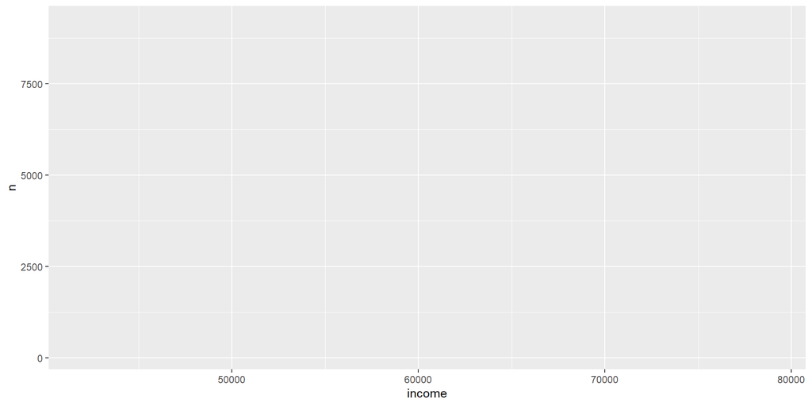

```r
plt<-ggplot(ccc_states_summary, aes(x=income, y=n))

plt
```

## ggplot geometry

Now we need to populate the space with data. We’ll use “geometries” like `geom_point()`, `geom_bar()`, `geom_density()` etc. to specify the kind of plot we want.

Note we use the `+` to add more stuff to our existing plot:

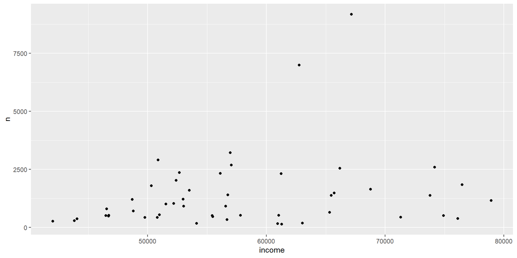

```r
# the intial plot:
plt<- ggplot(ccc_states_summary, aes(x=income, y=n))

# now with some geometries:

plt<- plt +
  geom_point()

plt
```

## ggplot axes

`ggplot` syntax allows you to build plots step-by-step, adding new stuff as you go and then checking your results. I might want to add axis labels:

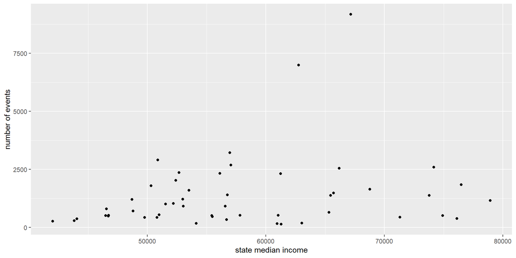

```r
plt<- ggplot(ccc_states_summary, aes(x=income, y=n))

plt<- plt +
  geom_point()

# now with axis labels
plt<-plt +
  ylab("number of events") +
  xlab("state median income")

plt
```

## ggplot themes

I can also alter the theme or make additional aesthetic changes as I go. I’m personally not a huge fan of the default ggplot theme so you’ll often see calls to `theme_bw()` or `theme_minimal()` in my code. You can check out the various theme options [here.](https://ggplot2.tidyverse.org/reference/ggtheme.html)

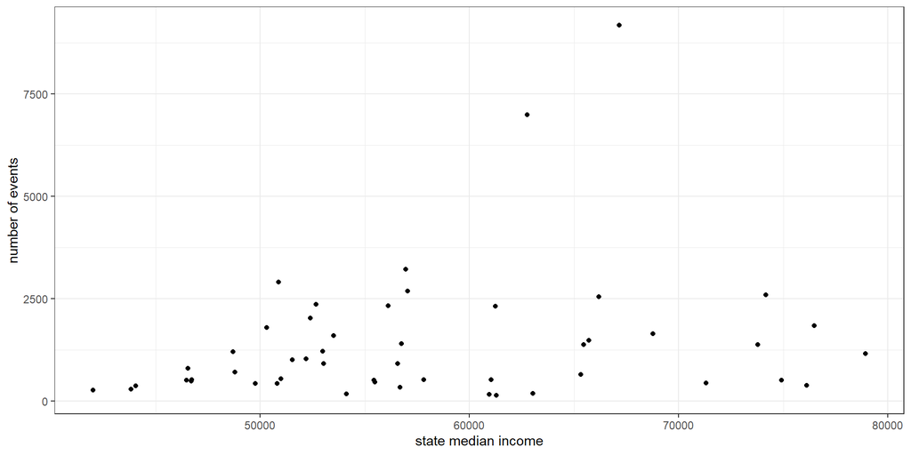

```r
plt<- ggplot(ccc_states_summary, aes(x=income, y=n))

plt<- plt +
  geom_point()

plt<-plt +
  ylab("number of events") +
  xlab("state median income") +
  theme_bw()

plt
```

## ggplot additional geometry

`ggplot` objects aren’t limited to a single geometry. If we wanted to add something like a smoothed trend line to this data, we just need to add `geom_smooth()` to the existing plot:

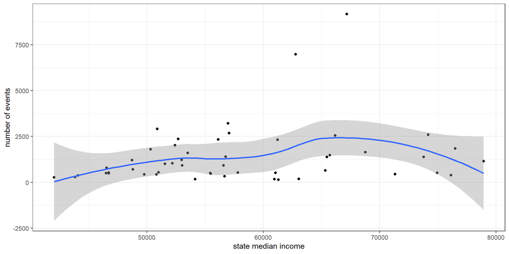

```r
plt<- ggplot(ccc_states_summary, aes(x=income, y=n))

plt<- plt +
  geom_point()

plt<-plt +
  ylab("number of events") +
  xlab("state median income") +
  theme_bw()

plt <- plt + geom_smooth()

plt
```

# ggplot resources

Aside from the [extensive online documentation](https://ggplot2.tidyverse.org/reference/), the [R-graph Gallery is a good showcase](https://r-graph-gallery.com/) for things you can do.